# Evidencia | Proyecto integrador

Diana Barreto, Sofía Ocampo Moreno, Aaron Flores Cerón

2026-06-16

# Comparación de mutaciones en el gen Spike del SARS-CoV-2 entre México y otras regiones del mundo durante 2021

## Introducción

> La pandemia de COVID-19, causada por el virus SARS-CoV-2, generó una crisis sanitaria como ninguna otra. Desde su identificación en el 2019, el virus ha acumulado mutaciones que han dado origen a diferentes variantes, cada una con características distintas, mayor transmisibilidad o capacidad de evasión inmunológica, entre otras características..

## Contexto

> El genoma del SARS-CoV-2 contiene 11 genes principales:
> - ORF1ab
> - S (Spike)
> - ORF3a
> - E (Envelope)
> - M (Membrane)
> - ORF6
> - ORF7a
> - ORF7b
> - ORF8
> - N (Nucleocapsid)
> - ORF10

> El gen ORF1ab ocupa aproximadamente dos terceras partes del genoma y codifica proteínas involucradas en la replicación viral. Los genes S,E,M y N codifican las principales proteínas estructurales del virus. El gen S es particularmente importante porque produce la proteína Spike, la responsable de la entrada del virus a las células mediante interacción con el receptor ACE2. Debido a su papel en la infección y en la respuesta inmunitaria, esta región presenta numerosas mutaciones asociadas con variantes de interés

## Hipótesis

> Las secuencias del gen Spike del SARS-CoV-2 obtenidas en México durante 2021 presentarán diferencias en aminoácidos características con secuencias provenientes de Estados Unidos, Reino Unido, China y Brasil del mismo periodo, indicando la circulación internacional de lineajes virales relacionados. Sin embargo, también se observarán diferencias regionales asociadas a la prevalencia local de variantes específicas.

## Procesamiento de datos

```r
library(seqinr)

mexico <- read.fasta("data/mexico_S_2021.fasta")
usa <- read.fasta("data/usa_S_2021.fasta")
uk <- read.fasta("data/uk_S_2021.fasta")
china <- read.fasta("data/china_S_2021.fasta")
brazil <- read.fasta("data/brazil_S_2021.fasta")
```

### Datos a utilizar

> Se descargaron secuencias de la proteína Spike (S) del SARS-CoV-2 desde la base de datos NCBI Virus. Se seleccionaron cinco secuencias de México, Estados Unidos, Reino Unido, China y Brasil correspondientes al año 2021. Todas las secuencias fueron obtenidas en formato FASTA e importadas a R para su análisis comparativo.

### Procedimiento general

> Las secuencias fueron organizadas por país y almacenadas en archivos FASTA independientes. Posteriormente se utilizó la librería seqinr para importar las secuencias a R. Se verificó el número de secuencias cargadas por país y la longitud de las proteínas Spike para asegurar la correcta importación de los datos. Finalmente, las secuencias fueron comparadas para identificar diferencias asociadas a posibles mutaciones.

### Construcción del dataframe

```r
datos <- data.frame(
  Pais = c("México","Estados Unidos","Reino Unido",
           "China","Brasil"),
  Longitud = c(
    length(mexico[[1]]),
    length(usa[[1]]),
    length(uk[[1]]),
    length(china[[1]]),
    length(brazil[[1]])
  )
)

datos
```

```
##             Pais Longitud
## 1         México     1273
## 2 Estados Unidos     1270
## 3    Reino Unido     1270
## 4          China     1273
## 5         Brasil     1273
```

> Se construyó un dataframe denominado “datos”, el cual almacena el país de origen de cada secuencia y la longitud de una proteína Spike representativa. Este dataframe se utilizó para generar tablas y gráficas comparativas que permitieron resumir la información obtenida de las secuencias descargadas.

> El flujo de información consistió en la descarga de secuencias Spike desde NCBI Virus, su almacenamiento en archivos FASTA, la importación a R mediante seqinr y la construcción de data frames para resumir longitudes y diferencias entre secuencias. Posteriormente se generaron tablas y gráficas para visualizar los resultados obtenidos.

## Resultados

### Dataframe generado

```r
datos
```

```
##             Pais Longitud
## 1         México     1273
## 2 Estados Unidos     1270
## 3    Reino Unido     1270
## 4          China     1273
## 5         Brasil     1273
```

### Número de secuencias analizadas

```r
data.frame(
  Pais = c("México","Estados Unidos","Reino Unido","China","Brasil"),
  Secuencias = c(length(mexico),
                 length(usa),
                 length(uk),
                 length(china),
                 length(brazil))
)
```

```
##             Pais Secuencias
## 1         México          5
## 2 Estados Unidos          5
## 3    Reino Unido          5
## 4          China          5
## 5         Brasil          5
```

### Longitud de las secuencias analizadas

```r
data.frame(
  Pais = c("México","Estados Unidos","Reino Unido",
           "China","Brasil"),
  Longitud = c(
    length(mexico[[1]]),
    length(usa[[1]]),
    length(uk[[1]]),
    length(china[[1]]),
    length(brazil[[1]])
  )
)
```

```
##             Pais Longitud
## 1         México     1273
## 2 Estados Unidos     1270
## 3    Reino Unido     1270
## 4          China     1273
## 5         Brasil     1273
```

> Las secuencias Spike analizadas presentaron longitudes entre 1270 y 1273 aminoácidos. Estas diferencias son pequeñas y sugieren que la estructura general de la proteína Spike se conserva entre las distintas regiones estudiadas.

### Comparación de una región de la proteína Spike

```r
head(data.frame(
  Posicion = 1:50,
  Mexico = mexico[[1]][1:50],
  USA = usa[[1]][1:50],
  UK = uk[[1]][1:50],
  China = china[[1]][1:50],
  Brazil = brazil[[1]][1:50]
), 20)
```

```
##    Posicion Mexico USA UK China Brazil
## 1         1      m   m  m     m      m
## 2         2      f   f  f     f      f
## 3         3      v   v  v     v      v
## 4         4      f   f  f     f      f
## 5         5      l   l  l     l      l
## 6         6      v   v  v     v      v
## 7         7      l   l  l     l      l
## 8         8      l   l  l     l      l
## 9         9      p   p  p     p      p
## 10       10      l   l  l     l      l
## 11       11      v   v  v     v      v
## 12       12      s   s  s     s      s
## 13       13      s   s  s     s      s
## 14       14      q   q  q     q      q
## 15       15      c   c  c     c      c
## 16       16      v   v  v     v      v
## 17       17      n   n  n     n      n
## 18       18      l   f  l     l      l
## 19       19      t   t  t     t      t
## 20       20      t   t  t     t      n
```

### Comparación de longitudes

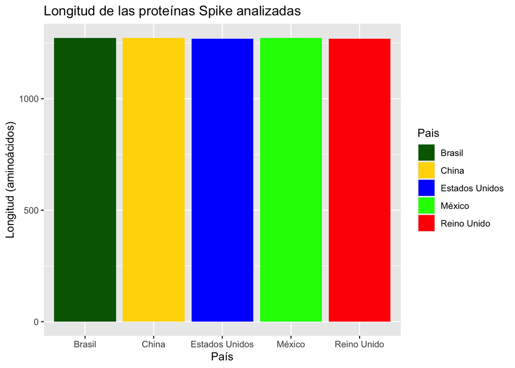

```r
longitudes <- c(
  length(mexico[[1]]),
  length(usa[[1]]),
  length(uk[[1]]),
  length(china[[1]]),
  length(brazil[[1]])
)

library(ggplot2)

ggplot(datos, aes(x = Pais, y = Longitud, fill = Pais)) +
  geom_col() +
  scale_fill_manual(values = c(
    "México" = "green",
    "Estados Unidos" = "blue",
    "Reino Unido" = "red",
    "China" = "gold",
    "Brasil" = "darkgreen"
  )) +
  labs(
    title = "Longitud de las proteínas Spike analizadas",
    x = "País",
    y = "Longitud (aminoácidos)"
  )
```

> Todas las secuencias analizadas presentaron longitudes cercanas a los 1273 aminoácidos, valor esperado para la proteína Spike del SARS-CoV-2. Las pequeñas diferencias observadas pueden deberse a regiones no determinadas o información faltante en algunas secuencias.

### Comparación de aminoácidos entre México y China

```r
comparacion_MC <- data.frame(
  Posicion = which(mexico[[1]] != china[[1]]),
  Mexico = mexico[[1]][which(mexico[[1]] != china[[1]])],
  China = china[[1]][which(mexico[[1]] != china[[1]])]
)

comparacion_MC
```

```
##    Posicion Mexico China
## 1       307      i     t
## 2       309      e     x
## 3       401      x     v
## 4       402      x     i
## 5       403      x     r
## 6       404      x     g
## 7       405      x     d
## 8       406      x     e
## 9       407      x     v
## 10      408      x     r
## 11      409      x     q
## 12      410      x     i
## 13      411      x     a
## 14      412      x     p
## 15      413      x     g
## 16      414      x     q
## 17      415      x     t
## 18      416      x     g
## 19      417      x     k
## 20      418      x     i
## 21      419      x     a
## 22      732      a     t
```

> Se identificaron 22 diferencias entre las secuencias de México y China. Una parte importante de estas diferencias corresponde a posiciones marcadas como aminoácidos desconocidos (X), mientras que otras representan posibles cambios reales en la proteína Spike. Por ello, los resultados deben interpretarse considerando la calidad de las secuencias disponibles.

### Alineación de secuencias

```r
gen = mexico[[1]][300:315]
gen2 = china[[1]][300:315]
gen = c(" ", gen)
gen2 = c(" ", gen2)

m = matrix(data=0, nrow=length(gen2), ncol=length(gen))
m[1, ] = seq(0, -2*(length(gen)-1), -2)
m[ ,1] = seq(0, -2*(length(gen2)-1), -2)
for (fila in seq(2,length(gen2))){
  for (col in seq(2,length(gen))){
    if (gen[col]==gen2[fila]){
      d = m[fila-1,col-1] + 1 #match
    }else{
      d = m[fila-1,col-1] - 1 #missmatch
    }
    up = m[fila-1, col] - 2
    left = m[fila, col-1] - 2
    peso = max(d, up, left)
    m[fila,col] = peso
  }
}

cat("\n")
```

```r
cat("Matriz:\n")
```

```
## Matriz:
```

```r
fila = nrow(m)
col = ncol(m)

alineacion1 = c()
alineacion2 = c()

while(fila > 1 || col > 1){
  if(fila > 1 && col > 1){
    if(gen[col] == gen2[fila]){
      d = m[fila-1,col-1] + 1
    }else{
      d = m[fila-1,col-1] - 1
    }
  }else{
    d = -9999
  }

  if(fila > 1){
    up = m[fila-1,col] - 2
  }else{
    up = -9999
  }

  if(col > 1){
    left = m[fila,col-1] - 2
  }else{
    left = -9999
  }

  if(fila > 1 && col > 1 && m[fila,col] == d){
    alineacion1 = c(gen[col], alineacion1)
    alineacion2 = c(gen2[fila], alineacion2)
    fila = fila - 1
    col = col - 1
  }else if(col > 1 && m[fila,col] == left){
    alineacion1 = c(gen[col], alineacion1)
    alineacion2 = c("_", alineacion2)
    col = col - 1
  }else{
    alineacion1 = c("_", alineacion1)
    alineacion2 = c(gen2[fila], alineacion2)
    fila = fila - 1
  }
}

resultado = rbind(
  alineacion1,
  alineacion2
)

cat("Resultado:\n")
```

```
## Resultado:
```

```r
m
```

```
##       [,1] [,2] [,3] [,4] [,5] [,6] [,7] [,8] [,9] [,10] [,11] [,12] [,13]
##  [1,]    0   -2   -4   -6   -8  -10  -12  -14  -16   -18   -20   -22   -24
##  [2,]   -2    1   -1   -3   -5   -7   -9  -11  -13   -15   -17   -19   -21
##  [3,]   -4   -1    2    0   -2   -4   -6   -8  -10   -12   -14   -16   -18
##  [4,]   -6   -3    0    3    1   -1   -3   -5   -7    -9   -11   -13   -15
##  [5,]   -8   -5   -2    1    4    2    0   -2   -4    -6    -8   -10   -12
##  [6,]  -10   -7   -4   -1    2    5    3    1   -1    -3    -5    -7    -9
##  [7,]  -12   -9   -6   -3    0    3    6    4    2     0    -2    -4    -6
##  [8,]  -14  -11   -8   -5   -2    1    4    7    5     3     1    -1    -3
##  [9,]  -16  -13  -10   -7   -4   -1    2    5    6     4     2     0    -2
## [10,]  -18  -15  -12   -9   -6   -3    0    3    4     7     5     3     1
## [11,]  -20  -17  -14  -11   -8   -5   -2    1    2     5     6     4     2
## [12,]  -22  -19  -16  -13  -10   -7   -4   -1    0     3     4     7     5
## [13,]  -24  -21  -18  -15  -12   -9   -6   -3   -2     1     2     5     8
## [14,]  -26  -23  -20  -17  -14  -11   -8   -5   -2    -1     0     3     6
```

[output cut: 21 more lines]

```r
print(resultado)
```

```
##             [,1] [,2] [,3] [,4] [,5] [,6] [,7] [,8] [,9] [,10] [,11] [,12]
## alineacion1 "k"  "c"  "t"  "l"  "k"  "s"  "f"  "i"  "v"  "e"   "k"   "g"
## alineacion2 "k"  "c"  "t"  "l"  "k"  "s"  "f"  "t"  "v"  "x"   "k"   "g"
##             [,13] [,14] [,15] [,16]
## alineacion1 "i"   "y"   "q"   "t"
## alineacion2 "i"   "y"   "q"   "t"
```

> Se realizó una alineación global entre un fragmento de las secuencias Spike de México y China utilizando el algoritmo Needleman-Wunsch con puntuaciones de +1 para coincidencias, -1 para diferencias y -2 para gaps. La alineación permitió identificar posiciones conservadas y regiones donde existen diferencias entre ambas secuencias.

### Comparación del número de diferencias observadas

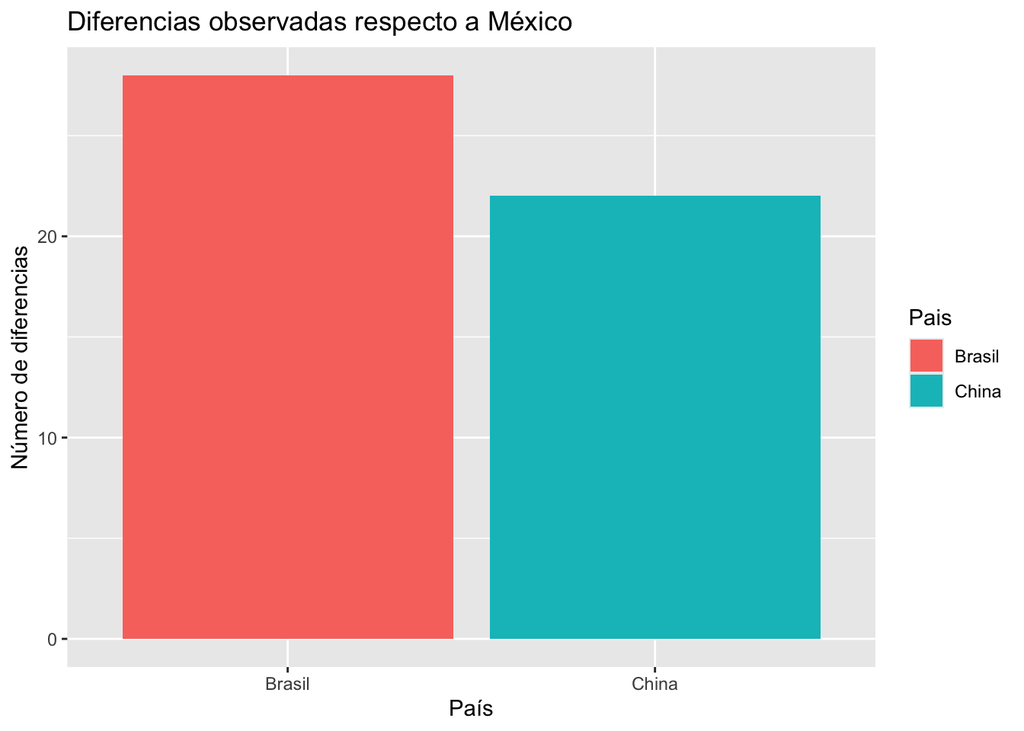

```r
mutaciones <- data.frame(
  Pais = c("China","Brasil"),
  Diferencias = c(
    sum(mexico[[1]] != china[[1]]),
    sum(mexico[[1]] != brazil[[1]])
  )
)

ggplot(mutaciones,
       aes(x = Pais,
           y = Diferencias,
           fill = Pais)) +
  geom_col() +
  labs(
    title = "Diferencias observadas respecto a México",
    x = "País",
    y = "Número de diferencias"
  )
```

> La secuencia de Brasil presentó un número ligeramente mayor de diferencias respecto a la secuencia de México que la observada para China. Esto sugiere la presencia de variaciones regionales en la proteína Spike, aunque la mayoría de la secuencia permanece conservada.

```r
resumen <- data.frame(
  Comparacion = c(
    "México-China",
    "México-Brasil"
  ),
  Diferencias = c(
    sum(mexico[[1]] != china[[1]]),
    sum(mexico[[1]] != brazil[[1]])
  )
)

resumen
```

```
##     Comparacion Diferencias
## 1  México-China          22
## 2 México-Brasil          28
```

> Brasil presentó 28 diferencias respecto a México, mientras que China presentó 22 diferencias. Esto indica que la secuencia analizada de China mostró una mayor similitud con la secuencia mexicana que la secuencia analizada de Brasil.

## Conclusiones

> Estos resultados sugieren que durante 2021 el SARS-CoV-2 continuó acumulando cambios en la proteína Spike conforme circulaba en distintas regiones del mundo. Debido a que esta proteína participa directamente en el reconocimiento del receptor ACE2 y en la entrada del virus a las células humanas, las mutaciones presentes en ella pueden influir en características como la transmisibilidad viral o la capacidad de evasión inmunológica. En conjunto, los resultados apoyan la idea de que la evolución del SARS-CoV-2 durante la pandemia estuvo acompañada por la aparición de variaciones regionales, aunque conservando gran parte de la estructura funcional de la proteína Spike.

## Referencias

Jackson, C. B., Farzan, M., Chen, B., & Choe, H. (2021). Mechanisms of SARS-CoV-2 entry into cells. Nature Reviews Molecular Cell Biology, 23(1), 3-20. https://doi.org/10.1038/s41580-021-00418-x

Sinha, A., Sangeet, S., & Roy, S. (2023). Evolution of Sequence and Structure of SARS-CoV-2 Spike Protein: A Dynamic Perspective. ACS Omega, 8(26), 23283-23304. https://doi.org/10.1021/acsomega.3c00944